# 17. Linear Regression 4 (Interaction 1)

Masahiko Asano

2024-01-13

- `R packages we use in this section`

```r
library(tidyverse)
library(stargazer)
library(margins)
library(interplot)
library(msm)
library(patchwork)
library(jtools)
```

# 1. What is interaction effects?

- Interaction effects occur when the effect of one variable depends on the value of another variable.
- Interaction effects are commonly used in regression analysis and designed experiments.
- In this section, I explain interaction effects and how to interpret them in statistical designs.

### What is the difference between a dummmy variable and an iteraction term?

- When we include a party dummy variable (`ldp`), then we can see **the difference in outcome variable (`voteshare`)** between LDP candidates (`ldp = 1`) and non-LDP candidates(`ldp = 0`) as shown in the graph on the left.

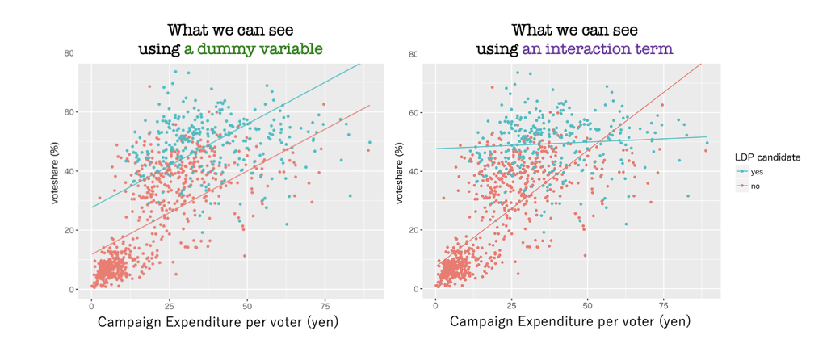

- Interaction effects indicate that a third variable (in this example, `ldp`) influences the relationship between an explanatory and outcome variable.
- When we include an interaction term (`ldp:exppv`), then we can see **the difference in slope (`exppv` → `voteshare`)** between LDP candidates (`ldp = 1`) and non-LDP candidates(`ldp = 0`) as shown in the graph on the right.
- This type of effect makes the model more complex, but if the real world actually behaves this way, it is critical to incorporate it in your model.

# 2. Model_1

- The following is the model we use in this section:

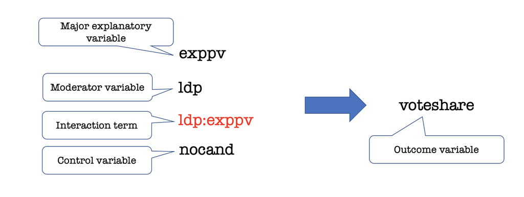

- `nocand` is control variable

Note ・**A control variable** is anything that is held constant or limited in a research study.  
・It’s a variable that is not of interest to our research aims, but is controlled because it could influence the outcomes.  
・In actual research, we need to add more control variables because it is reasonable for us to assume other variables (such as age of candidates, campaign expenditure, candidate’s gender, etc.) which could influence the votes share.  
・Here I only add `nocand` as control variable.

## 2.1 Marginal Effects

- To see interaction effects, we make an interaction term by multiplying the major independent variable (in this case, `exppv`) and a categorical moderator variable (in this case, `ldp`): **`ldp:exppv`**
- We make an interaction term by multiplying the following two independent variables:
1. major explanatory variable (`exppv`)
2. moderator variable (`ldp`)

Note ・A moderator variable can be two types: categorical and continuous variables.  
・In this section, I will deal with a moderator variable (categorical).  
・In `21. Multiple Regression 4 (Interaction Effects 2)`, I will deal with a moderator variable (continuous).

- We include this interaction term in Model_1
- This way, we can see how a third variable (`ldp`) influences the relationship between an explanatory and outcome variable.

#### Assumption of model_1:

- The slope (exppv → voteshare) differs between LDP and non-LDP candidates.
- This slope is equivalent to **`Marginal Effect`**
- We estimate the following model:
  $$\mathrm{{voteshare}\ = \alpha_0 + \alpha_1
  exppv + \alpha_2 ldp + \alpha_3 ldp:exppv + \alpha_4 nocand +
  \varepsilon}$$
- We can rewrite the equation asa follows:

$$\mathrm{{voteshare}\ = \alpha_0 +
(\alpha_1 + \alpha_3 ldp) exppv + \alpha_2 ldp + \alpha_4 nocand +
\varepsilon}$$

| $\alpha_0$ | : vote share (%) of a non-LDP member (`ldp = 0`) when `exppv = 0` |
| --- | --- |
| $(\alpha_1 + \alpha_3 \textrm{ldp})$ | slope (`exppv` → `voteshare`) = Marginal Effect |

#### WHAT WE WANT TO KNOW:

**Does the impact of campaign expenditure on vote share differ between LDP candidates and non-LDP candidates?**

- When we estimate a model with an interaction term, we need to check **Marginal Effects**

Marginal Effects ・Marginal effects are often calculated when analyzing regression analysis results.  
・Marginal effects are equivalent to `slopes` in regression analysis.  
・Marginal effects tells us how a dependent variable (outcome) changes when a specific independent variable (explanatory variable) changes.  
・Other covariates (= control variables) are assumed to be held constant.  
→ In this case, we hold `nocand` constant.

## 2.2 Date preparation

- Download hr96_17.csv
- Japanese lower house election results (1996-2017)
- Put the file (hr96_17.csv) into `data` folder in your `RProject` folder
- Load the data and name it `hr`

```r
hr <- read_csv("data/hr96-17.csv",
               na = ".")
```

- Check the variable names in `hr`

```r
names(hr)
```

```
 [1] "year"          "pref"          "ku"            "kun"
 [5] "wl"            "rank"          "nocand"        "seito"
 [9] "j_name"        "gender"        "seshu_dummy"   "jiban_seshu"
[13] "name"          "previous"      "...15"         "age"
[17] "exp"           "status"        "vote"          "voteshare"
[21] "eligible"      "turnout"       "castvotes"     "...24"
[25] "...25"         "nojiban_seshu" "mag"
```

- Check how many lower elections we had since 1996 to date

```r
unique(hr$year)
```

```
[1] 1996 2000 2003 2005 2009 2012 2014 2017 2021
```

```r
df1 <- hr %>%
  dplyr::filter(year == 2005) %>%
  dplyr::select(year, voteshare, exp, eligible,  seito, nocand)
```

- Check df1

```r
DT::datatable(df1)
```

|  | year | voteshare | exp | eligible | seito | nocand |
| --- | --- | --- | --- | --- | --- | --- |
| 1 | 2005 | 50 | 6136854 | 360007 | 民主 | 4 |
| 2 | 2005 | 39.1 | 14409252 | 360007 | 自民 | 4 |
| 3 | 2005 | 3.6 | 4702496 | 360007 | 社民 | 4 |
| 4 | 2005 | 7.4 | 2177427 | 360007 | 共産 | 4 |
| 5 | 2005 | 39.1 | 5289828 | 366121 | 自民 | 3 |
| 6 | 2005 | 52 | 11075148 | 366121 | 民主 | 3 |
| 7 | 2005 | 8.9 | 2016750 | 366121 | 共産 | 3 |
| 8 | 2005 | 49 | 7005984 | 367839 | 民主 | 4 |
| 9 | 2005 | 9 | 1580848 | 367839 | 共産 | 4 |
| 10 | 2005 | 3.8 | 641455 | 367839 | 無所属 | 4 |

[output cut: 979 more lines]

`df1` contains the following 6 variables

| variable | detail |
| --- | --- |
| year | Election Year |
| voteshare | Voteshare (%) |
| exp | Election expenditure (yen) spent by each candidate |
| eligible | Eligible voters in each district |
| seito | Candidate’s affiliated party |
| nocand | Number of candidates in each district |

```r
df1 <- df1 %>%
  mutate(ldp = ifelse(seito == "自民", 1, 0))
```

- We need campaign expenditure variable (`exppv`)
- `exppv` show campaign expenditure spent by each candidate per voter in their electoral district.

```r
df1 <- mutate(df1, exppv = exp / eligible)
```

```r
DT::datatable(df1)
```

|  | year | voteshare | exp | eligible | seito | nocand | ldp | exppv |
| --- | --- | --- | --- | --- | --- | --- | --- | --- |
| 1 | 2005 | 50 | 6136854 | 360007 | 民主 | 4 | 0 | 17.04648520723208 |
| 2 | 2005 | 39.1 | 14409252 | 360007 | 自民 | 4 | 1 | 40.02492173763288 |
| 3 | 2005 | 3.6 | 4702496 | 360007 | 社民 | 4 | 0 | 13.06223490098804 |
| 4 | 2005 | 7.4 | 2177427 | 360007 | 共産 | 4 | 0 | 6.048290727680295 |
| 5 | 2005 | 39.1 | 5289828 | 366121 | 自民 | 3 | 1 | 14.44830534167666 |
| 6 | 2005 | 52 | 11075148 | 366121 | 民主 | 3 | 0 | 30.24996654111619 |
| 7 | 2005 | 8.9 | 2016750 | 366121 | 共産 | 3 | 0 | 5.508424810376897 |
| 8 | 2005 | 49 | 7005984 | 367839 | 民主 | 4 | 0 | 19.04633277058713 |
| 9 | 2005 | 9 | 1580848 | 367839 | 共産 | 4 | 0 | 4.297662836186483 |
| 10 | 2005 | 3.8 | 641455 | 367839 | 無所属 | 4 | 0 | 1.743847172268302 |

[output cut: 979 more lines]

- Show the descriptive statistics of `df1`

```r
stargazer(as.data.frame(df1), type = "html")
```

| Statistic | N | Mean | St. Dev. | Min | Max |
| --- | --- | --- | --- | --- | --- |
| year | 989 | 2,005.000 | 0.000 | 2,005 | 2,005 |
| voteshare | 989 | 30.333 | 19.230 | 0.600 | 73.600 |
| exp | 985 | 8,142,244.000 | 5,569,641.000 | 62,710 | 24,649,710 |
| eligible | 989 | 344,654.300 | 63,898.230 | 214,235 | 465,181 |
| nocand | 989 | 3.435 | 0.740 | 2 | 6 |
| ldp | 989 | 0.293 | 0.455 | 0 | 1 |
| exppv | 985 | 24.627 | 17.907 | 0.148 | 89.332 |

## 2.3 Results (Model_1)

```r
model_1 <- lm(voteshare ~ exppv*ldp + nocand,
              data = df1)
```

#### Visually show the results: `jtools::plot_summs()`

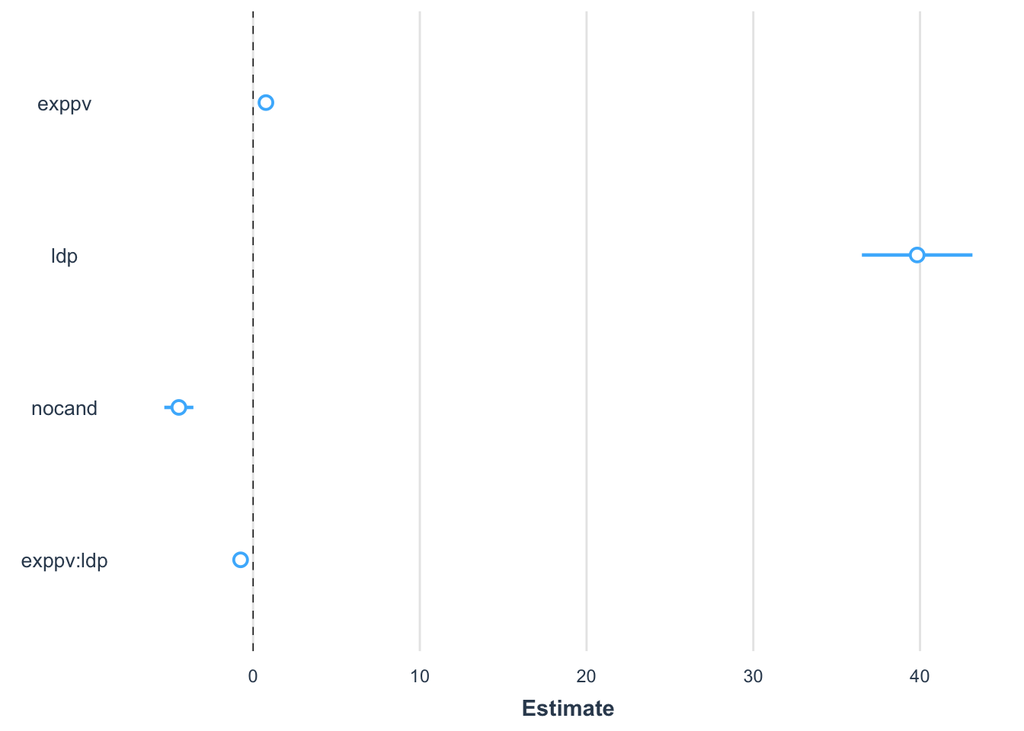

```r
jtools::plot_summs(model_1)
```

#### Show the results: `tidy()`

```r
tidy(model_1)
```

```
# A tibble: 5 × 5
  term        estimate std.error statistic   p.value
  <chr>          <dbl>     <dbl>     <dbl>     <dbl>
1 (Intercept)   23.5      1.70        13.8 1.27e- 39
2 exppv          0.770    0.0250      30.7 7.15e-146
3 ldp           39.8      1.69        23.6 1.08e- 97
4 nocand        -4.45     0.444      -10.0 1.41e- 22
5 exppv:ldp     -0.749    0.0453     -16.5 2.72e- 54
```

#### Show the results: `stargazer()`

```r
stargazer(model_1,
          digits = 3,
          style = "ajps",
          title = "Results of model_1 (2005HR election)",
          type ="html")
```

**Results of model(2005HR election)**

|  | **voteshare** |
| --- | --- |
| exppv | 0.770*** |
|  | (0.025) |
| ldp | 39.830*** |
|  | (1.690) |
| nocand | -4.453*** |
|  | (0.444) |
| exppv:ldp | -0.749*** |
|  | (0.045) |
| Constant | 23.459*** |
|  | (1.702) |
| N | 985 |
| R-squared | 0.723 |
| Adj. R-squared | 0.722 |
| Residual Std. Error | 10.130 (df = 980) |
| F Statistic | 639.244*** (df = 4; 980) |
| p < .01; p < .05; p < .1 |  |

- We see that all variables are statistically significant.
- Next, we need to interpret the results.

## 2.4 Interpretation (model_1)

- In interpreting `model_1`, let’s make another model which does not include the interaction term (`model_2`) and compare them to have a better understanding of the results.

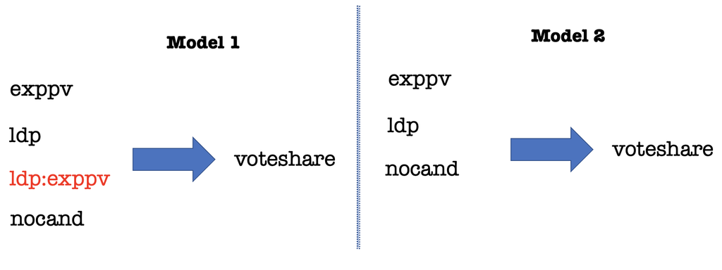

- Let’s make model_2

```r
model_2 <- lm(voteshare ~ exppv + ldp + nocand,
              data = df1)
```

#### Show the results: `stargazer()`

```r
stargazer(model_1, model_2,
          digits = 3,
          style = "ajps",
          title = "Results of model_1 and model_2(2005HR election)",
          type ="html")
```

|  | **voteshare** |  |
| --- | --- | --- |
|  | **Model 1** | **Model 2** |
| exppv | 0.770*** | 0.543*** |
|  | (0.025) | (0.024) |
| ldp | 39.830*** | 15.423*** |
|  | (1.690) | (0.927) |
| nocand | -4.453*** | -4.403*** |
|  | (0.444) | (0.502) |
| exppv:ldp | -0.749*** |  |
|  | (0.045) |  |
| Constant | 23.459*** | 27.558*** |
|  | (1.702) | (1.903) |
| N | 985 | 985 |
| R-squared | 0.723 | 0.646 |
| Adj. R-squared | 0.722 | 0.645 |
| Residual Std. Error | 10.130 (df = 980) | 11.448 (df = 981) |
| F Statistic | 639.244*** (df = 4; 980) | 596.035*** (df = 3; 981) |
| p < .01; p < .05; p < .1 |  |  |

Important point **The results of Model_1 is the results when ldp = 0**

- The coefficient of `exppv` (0.770) in model_1  
  → when `exppv` increased one yen, `voteshare` increased by 0.77 percentage points [when a candidate is not an LDP]
- To confirm this, let’s check the Sample Regression Function equations for model_1.

$$\widehat{voteshare}\ = 23.459 +
0.77exppv -0.749ldp:exppv - 4.453nocand$$
$$= 23.459 + (0.77 - 0.749ldp)exppv -
4.453nocand$$

- The impact of `exppv` on `voteshare` $(α_1 + α_3ldp)$ is:

$${0.77 -
0.749ldp}$$

- **0.77 - 0.749ldp** means the marginal effect（`exppv` → `voteshare`）when a candidate increases his/her campaign expenditure by 1 yen per voter
- We see that marginal effects change depending on the value of `ldp`
- Thus, we get the following two equations depending on the value of `ldp`:

### Model_1

#### When ldp = 0

$$\textrm{voteshare}= 23.46 + 0.77 \cdot
\textrm{exppv} - 4.45 \cdot \textrm{nocand} +
\varepsilon$$

- Let’s visualize Model_1

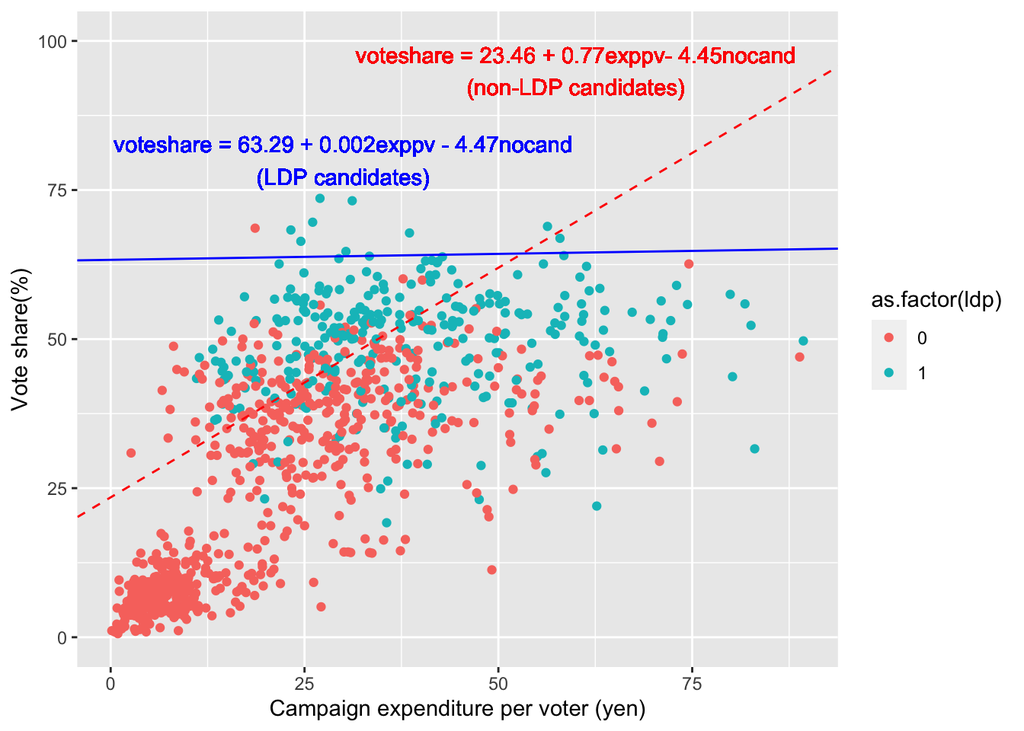

```r
plot1 <- ggplot(df1, aes(x = exppv, y = voteshare)) +
  geom_point(aes(color = as.factor(ldp))) +
  geom_abline(intercept = 23.46, slope = 0.77, linetype = "dashed", color = "red") +
  geom_abline(intercept = 63.29, slope = 0.02, color = "blue") +
  ylim(0, 100) +
  labs(x = "Campaign expenditure per voter (yen)", y = "Vote share(%)") +
  geom_text(label = "voteshare = 23.46 + 0.77exppv- 4.45nocand\n(non-LDP candidates)",
            x = 60, y = 95, color = "red") +
  geom_text(label = "voteshare = 63.29 + 0.002exppv - 4.47nocand\n(LDP candidates)",
            x = 30, y = 80,  color = "blue")
plot1
```

### Model_2

$$voteshare = 27.558 + 0.543exppv -
4.403$$

- Let’s visualize Model_2

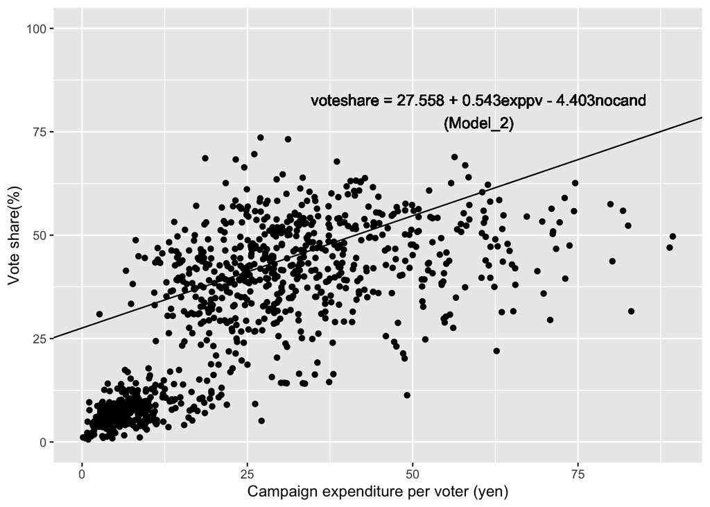

```r
plot2 <- ggplot(df1, aes(x = exppv, y = voteshare)) +
    geom_point() +
  geom_abline(intercept = 27.558, slope = 0.543, color = "black") +
  ylim(0, 100) +
  labs(x = "Campaign expenditure per voter (yen)", y = "Vote share(%)") +
  geom_text(label = "voteshare = 27.558 + 0.543exppv - 4.403nocand\n(Model_2)",
            x = 60, y = 80, color = "black")
plot2
```

### Visualize Marginal Effects (model_1)

#### `msm package`

```r
model_1$coef
```

```
(Intercept)       exppv         ldp      nocand   exppv:ldp
 23.4586397   0.7701405  39.8297455  -4.4525774  -0.7493132
```

- We need to calculate the marginal effects (= slopes) of `exppv` on `voteshare` when `ldp = 0` and `ldp = 1`.
- To calculate these two marginal effects, we use the 2nd value (`exppv`) and the 5th value (`exppv:ldp`)

```r
at.ldp <- c(0, 1)
slopes <- model_1$coef[2] + model_1$coef[5]*at.ldp

slopes
```

```
[1] 0.77014053 0.02082736
```

- Using the `delta method`, we calculate `standard error` on these two marginal effects with 95% confidence intervals

```r
library(msm)
```

```r
estmean <- coef(model_1)
var <- vcov(model_1)

SEs <- rep(NA, length(at.ldp))

for (i in 1:length(at.ldp)){
    j <- at.ldp[i]
    SEs[i] <- deltamethod (~ (x2) + (x5)*j, estmean, var)　# standard error
}

upper <- slopes + 1.96*SEs
lower <- slopes - 1.96*SEs

cbind(at.ldp, slopes, upper, lower)
```

```
     at.ldp     slopes      upper       lower
[1,]      0 0.77014053 0.81923536  0.72104569
[2,]      1 0.02082736 0.09518719 -0.05353247
```

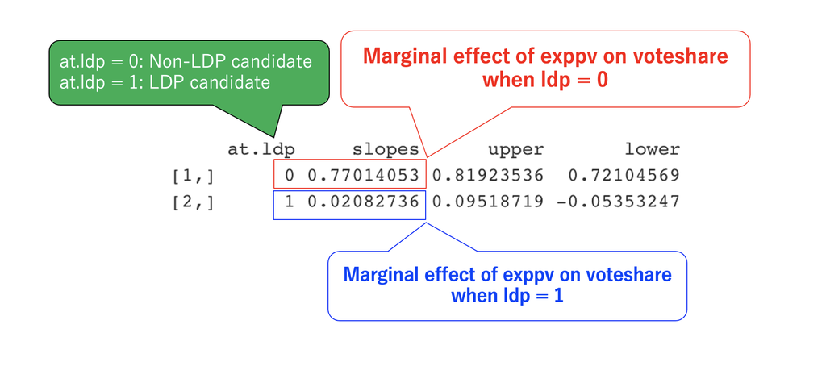

- Let me explain what this means.
- `at.ldp` shows whether a candidate belongs to the LDP (= 1) or not (= 0)
- `slopes` is the **marginal effects** of `exppv` on `voteshare`
- The value (0.77014053) between `[1, ]` and `slopes`  
  → The marginal effect of `exppv` on `voteshare` for a non-LDP candidate
- The value (0.02082736) between `[2, ]` and `slopes`  
  → The marginal effect of `exppv` on `voteshare` for an LDP candidate
- `upper` and `lower` show the upper bound and lower bound on 95% confidence intervals
- To visualize this result, we change the data into data frame and name it `msm_1`

```r
msm_1 <- cbind(at.ldp, slopes, upper, lower) %>%
  as.data.frame()

msm_1
```

```
  at.ldp     slopes      upper       lower
1      0 0.77014053 0.81923536  0.72104569
2      1 0.02082736 0.09518719 -0.05353247
```

- Draw a graph showing the marginal effects of `exppv` on `voteshare` for a Non-LDP and an LDP candidate.

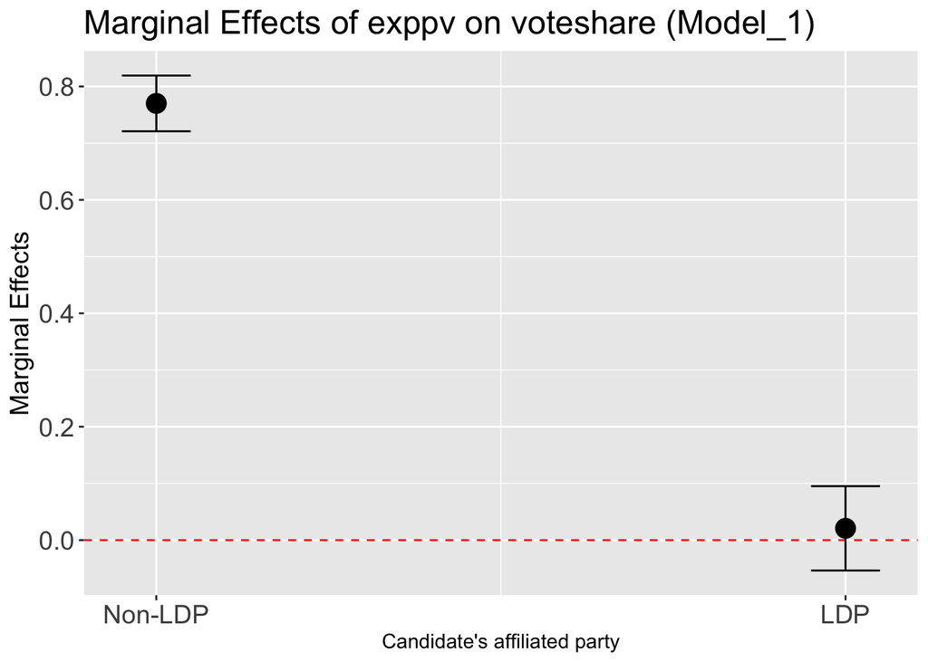

```r
msm_1 <- msm_1 %>%
  ggplot(aes(at.ldp, slopes, ymin = lower, ymax = upper)) +
  geom_hline(yintercept = 0, linetype = 2, col = "red") +
  geom_pointrange(size = 1) +
  geom_errorbar(aes(x = at.ldp, ymin = lower, ymax = upper),
                width = 0.1) +
  labs(x = "Candidate's affiliated party", y = "Marginal Effects") +
  scale_x_continuous(breaks = c(1,0),
                     labels = c("LDP", "Non-LDP")) +
  ggtitle("Marginal Effects of exppv on voteshare (Model_1)") +
  theme(axis.text.x  = element_text(size = 14),
        axis.text.y  = element_text(size = 14),
        axis.title.y = element_text(size = 14),
        plot.title   = element_text(size = 18))
msm_1
```

## 2.5 How to show your results

**Results of model(2005HR election)**

|  | **voteshare** |  |
| --- | --- | --- |
|  | **Model 1** | **Model 2** |
| exppv | 0.770*** | 0.543*** |
|  | (0.025) | (0.024) |
| ldp | 39.830*** | 15.423*** |
|  | (1.690) | (0.927) |
| nocand | -4.453*** | -4.403*** |
|  | (0.444) | (0.502) |
| exppv:ldp | -0.749*** |  |
|  | (0.045) |  |
| Constant | 23.459*** | 27.558*** |
|  | (1.702) | (1.903) |
| N | 985 | 985 |
| R-squared | 0.723 | 0.646 |
| Adj. R-squared | 0.722 | 0.645 |
| Residual Std. Error | 10.130 (df = 980) | 11.448 (df = 981) |
| F Statistic | 639.244*** (df = 4; 980) | 596.035*** (df = 3; 981) |
| p < .01; p < .05; p < .1 |  |  |

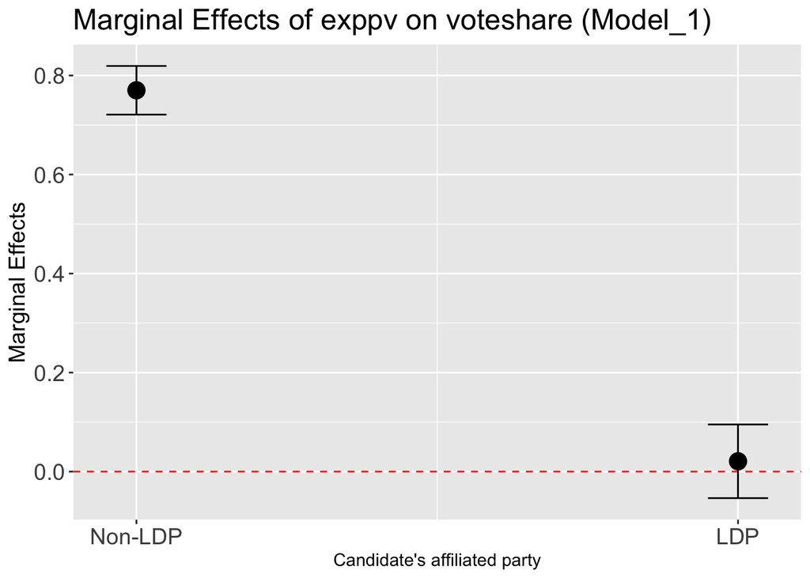

Results on model_1 **When ldp = 0**  
・When a non-LDP candidates increases campaign money by 1 yen, then his/her vote share increases by 0.77 percentage points.  
・This is statistically significant with the 1% significant level (`p-value = 7.15e-146`)

**When ldp = 1**  
・When an LDP candidate increases campaign money by 1 yen, then his/her vote share increases by 0.02 percentage points.  
・This is not statistically significant.

**The coefficient of exppv:ldp, -0.749**  
**・The impact of campaign expenditure on vote share differs between LDP candidates and non-LDP candidates.**  
・The difference in the impact of `exppv` on `voteshare` differs by 0.749.  
・A non-LDP candidate’s marginal effect (slope) is larger than a LDP candidat’s by 0.749 percentage points.  
・This is statistically significant with the 1% significant level (`p-value = 2.72e- 54`)

- If you want to check p-value, use either `tidy()` or `summary()`

```r
tidy(model_1)
```

```
# A tibble: 5 × 5
  term        estimate std.error statistic   p.value
  <chr>          <dbl>     <dbl>     <dbl>     <dbl>
1 (Intercept)   23.5      1.70        13.8 1.27e- 39
2 exppv          0.770    0.0250      30.7 7.15e-146
3 ldp           39.8      1.69        23.6 1.08e- 97
4 nocand        -4.45     0.444      -10.0 1.41e- 22
5 exppv:ldp     -0.749    0.0453     -16.5 2.72e- 54
```

# 3. Excercise.

- You want to investigate whether the impact of campaign expenses on the vote percentage differs between Democratic Party（民主）candidates and candidates from other parties.
- The data to be used here consists of general election results conducted from 1996 to 2021: hr96-21.csv.
- This dataset contains the following 23 variables.

| variable | detail |
| --- | --- |
| year | Election year (1996-2017) |
| pref | Prefecture |
| ku | Electoral district name |
| kun | Number of electoral district |
| rank | Ascending order of votes |
| wl | 0 = loser / 1 = single-member district (smd) winner / 2 = zombie winner |
| nocand | Number of candidates in each district |
| seito | Candidate’s affiliated party (in Japanese) |
| j_name | Candidate’s name (Japanese) |
| name | Candidate’s name (English) |
| previous | Previous wins |
| gender | Candidate’s gender:“male”, “female” |
| age | Candidate’s age |
| exp | Election expenditure (yen) spent by each candidate |
| status | 0 = challenger / 1 = incumbent / 2 = former incumbent |
| vote | votes each candidate garnered |
| voteshare | Voteshare (%) |
| eligible | Eligible voters in each district |
| turnout | Turnout in each district (%) |
| castvote | Total votes cast in each district |
| seshu_dummy | 0 = Not-hereditary candidates, 1 = hereditary candidate |
| jiban_seshu | Relationship between candidate and his predecessor |
| nojiban_seshu | Relationship between candidate and his predecessor |

- Please extract data from 2009 and the following 6 variables for analysis:

| Variable Names | Description |
| --- | --- |
| voteshare | Vote Percentage (%) |
| exppv | Campaign Expenses per Eligible Voter (yen) |
| dpj | Democratic Party Dummy (Democratic Party Candidate = 1, Other Candidates = 0) |
| previous | Number of Previous Wins by the Candidate |
| age | Age of the Candidate |
| nocand | Number of Candidates in the Election |

- `Note 1`: The variable dpj is not included in the dataset, so you should create it individually using the seito or party variable.
- `Note 2`: The variable exppv is not included in the dataset, so you should create it individually using the exp and eligible variables.

**Q2**: Display a scatter plot of campaign expenses and vote percentage and provide a brief comment.

**Q3**: State your hypothesis regarding whether the impact of campaign expenses on vote percentage differs between Democratic Party candidates and candidates from other parties in House of Representatives elections. Also, briefly explain the reasoning behind your hypothesis.

**Q4**: Can we say that the impact of campaign expenses on vote percentage is different between Democratic Party candidates and candidates from other parties? Use the msm package to visualize the marginal effect of campaign expenses on vote percentage for both Democratic Party candidates and other candidates, and explain the results succinctly.

**References**

[宋財泫 (Jaehyun Song)・矢内勇生 (Yuki Yanai)「私たちのR: ベストプラクティスの探究」](https://www.jaysong.net/RBook/)

[土井翔平（北海道大学公共政策大学院）「Rで計量政治学入門」](https://shohei-doi.github.io/quant_polisci/data-import.html)

[矢内勇生（高知工科大学）授業一覧](http://yukiyanai.github.io/teaching/)

浅野正彦, 矢内勇生.『Rによる計量政治学』オーム社、2018年

浅野正彦, 中村公亮.『初めてのRStudio』オーム社、2018年

Winston Chang, R Graphics Cookbook, O’Reilly Media, 2012.

Kieran Healy, DATA VISUALIZATION, Princeton, 2019

Kosuke Imai, Quantitative Social Science: An Introduction, Princeton University Press, 2017